# Testing Copilot Blog

Author

Luke Shaw

Published

January 19, 2024

## About

[GitHub Copilot](https://github.com/features/copilot?) is an AI coding assistant, that I have been using for the past month when I code. This is a brief review of my experience and thoughts.

## The Good

### Easy to Get Started

I watched [this video](https://www.youtube.com/watch?v=yVq-b5xHmac) about how it works, and it was quick to get started once I decided to try it.

My IDE of choice is RStudio, and it was quick (under 5 mins) to get set up.

### I am more productive when I code

It definitely takes me less time to write code. It is a really good first-draft for functions. Below is a simple example below that took less than a second to give the suggestion once I had written the comment above:

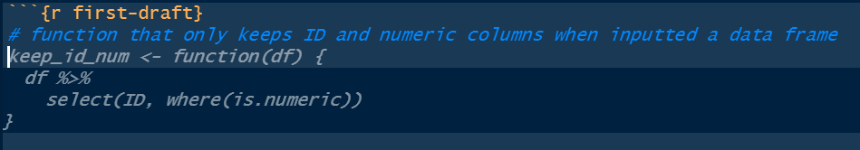

First Draft Example

It also saves a lot of time on copying-pasting as it uses what is already within the file to inform its suggestion. See how my syntax from the first function I wrote is copied below when I suggest a similar function, with the naming convention and subfunctions used. This is possibly good and bad, as it keeps my coding style but perhaps keeps me in a box, limiting what improvements to my code I can make

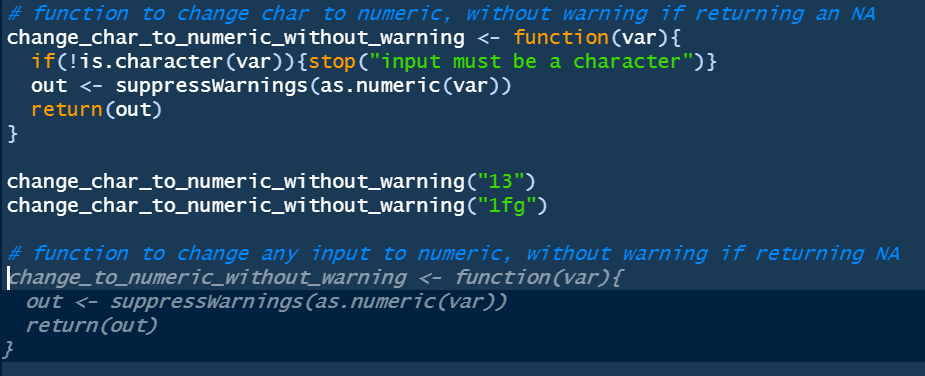

Copying Example

### Changing Languages

Like Chat GPT, it is great at helping you out if you know what to do but don’t know the syntax of the language you are in. For example, writing in python as an R user, or a similar use-case I had at work of altering a SQL script to get the table output I desired.

## The Bad

### Convincing but wrong

I am not too fussed if a first-draft example doesn’t work, I don’t expect it to and the boiler plate structure is still helpful to get me moving. However, there have been times when the code is passable when I’m not checking, and this could lead to errors. A very simple example of this is sometimes I add numeric outputs received as a comment above the code that executes, like the number of rows in a data frame.

At a very simple level, it seems copilot can anticipate small calculations. The problem, however, is it is convincing but wrong with the large calculations.

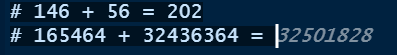

Large Calculation Example - Incorrect Suggestion

In the above image the third digit is a 5 when should be a 6 - but good luck spotting that!

### Quicker down the wrong path

GitHub Copilot makes it quicker to start coding and get to something, but this is often not the best way of coding. I have seen this first-hand in my month of coding, when over the Christmas break I was playing a card game with friends. Using copilot I enjoyed coding up the problem and getting to a shiny app that could calculate solutions to the card game, it felt about twice as fast as if I’d not been using copilot.

However, for the same task as part of a bigger project this approach would have been bad, as the code is not production-grade and was hacked together without an overarching structure in mind. This is not copilot’s fault, but it is appealing to use copilot to race to an output, which could lead to headaches further down the line.

With shiny, the [golem](https://engineering-shiny.org/planning-ahead.html) framework discusses a better approach to building production-grade apps, and a lot of the focus is on planning and structure. There is even a section titled **Don’t Rush into Coding**, and for me at least having Copilot is an incentive to rushing.

### Cost

As an individual, at time of writing [GitHub Copilot costs](https://docs.github.com/en/billing/managing-billing-for-github-copilot/about-billing-for-github-copilot) USD $10 a month, with the first month free. It is different for Businesses, and free for students and similar roles.

This is value for money for me at time of writing, but is of course highly dependent on how much coding one does.

## Conclusion

My workflow needs to change when using copilot to optimise the collaboration. More commenting, more planning –> both things I knew where part of good practice anyway.

I am naturally pessimistic. When I first saw the copilot, my immediate reaction was ‘there goes my job’. I have since realised this take I have is a wonderful cocktail of negative, lazy, and unhelpful.

I enjoy using copilot, and think it will become a useful tool in most coder’s toolbox.